# 主成分分析・因子分析の課題の解答例

藤野秀則,

2025-02-07

次のデータは主成分分析 ・因子分析の時の課題で出したデータである．

- Q1: 何かを選ぶ時は些細なことは気にしない
- Q2: 重要なことを決めるとき，些細な問題にこだわり多くの時間を費やす
- Q3: 決断を先送りにしようとする
- Q4: 重要な問題は，直前まで決定を延ばす
- Q5: 他の人が何を選ぶのか気になる
- Q6: 自分が選んだものが他の人と違うと不安になる
- Q7: 決断した後，その決断に後悔しない
- Q8: 決めた後で，間違ってしまったと思うことがよくある

このデータは因子分析を実施したところ，因子数4，Varimax回転，Pa推定の場合に，次のような因子構造となる．

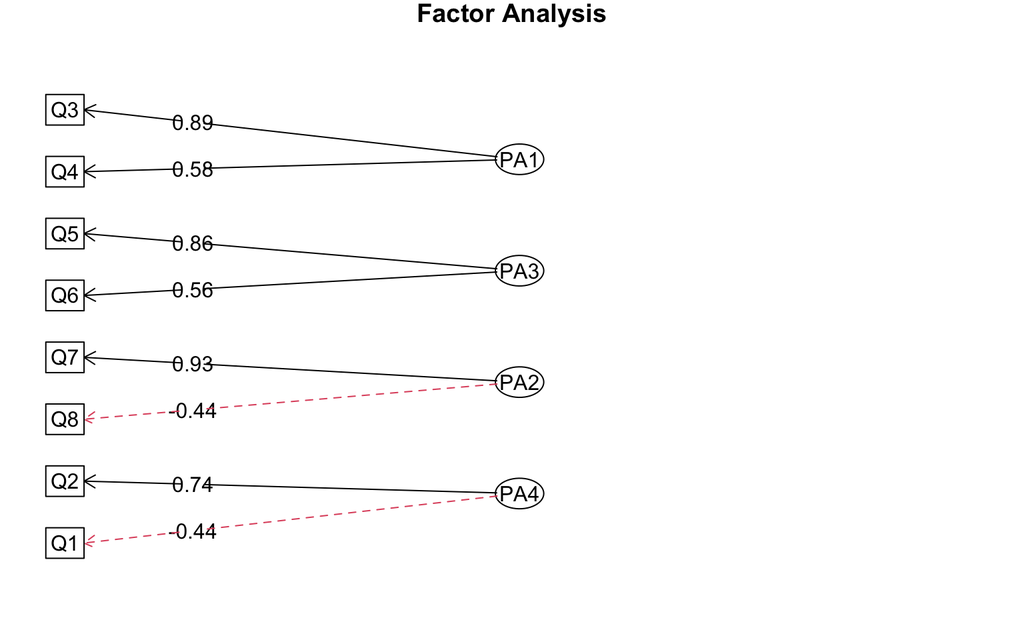

- 因子1（熟慮）: Q1, Q2
- 因子2（先延ばし）: Q3, Q4
- 因子3（他者参照）: Q5, Q6
- 因子4（不安）: Q7, Q8

実際にこの結果は文献(齊藤・緑川, 2016)の通りであり，もともとこれらの質問項目は文献に記載されている項目から因子負荷量の大きいものを2つずつ選んだものである．

さて，このデータについて，以下の問に答えよ．

1. 上記の因子について，それぞれ紐づいた質問の回答値を平均したものとをその因子の尺度として，熟慮，先延ばし，他者参照，不安の4つの尺度データを作成せよ．なお，逆転項目が含まれていることに注意すること．
2. 作成した4つの因子の尺度データを用いて，階層的クラスタリングを実施し，デンドログラムを表示させよ．
3. デンドログラムを基に，各自なりの判断でクラスター分けを実施し，各クラスタに含まれるサンプル数を示せ．
4. クラスター分けの結果を元に，各クラスタの平均値から各クラスターの特徴を述べよ．
5. 以上のことをk-means法でも実施し，結果を階層的クラスタリングの場合と比較せよ．

```r
library(tidyverse)
```

```
## ✖ ggplot2::%+%()   masks psych::%+%()
```

```r
data <- read.csv("./practice/13_work_fa.csv")

summary(data)
```

```
##   time_stamp              Q1              Q2             Q3
##  Length:308         Min.   :1.000   Min.   :1.00   Min.   :1.000
##  Class :character   1st Qu.:2.000   1st Qu.:3.00   1st Qu.:2.000
##  Mode  :character   Median :2.000   Median :4.00   Median :4.000
##                     Mean   :2.513   Mean   :3.86   Mean   :3.484
##                     3rd Qu.:3.000   3rd Qu.:5.00   3rd Qu.:5.000
##                     Max.   :5.000   Max.   :5.00   Max.   :5.000
##        Q4              Q5              Q6              Q7
##  Min.   :1.000   Min.   :1.000   Min.   :1.000   Min.   :1.000
##  1st Qu.:2.000   1st Qu.:4.000   1st Qu.:2.000   1st Qu.:2.000
##  Median :4.000   Median :4.000   Median :4.000   Median :3.000
##  Mean   :3.558   Mean   :3.896   Mean   :3.406   Mean   :2.896
##  3rd Qu.:5.000   3rd Qu.:5.000   3rd Qu.:5.000   3rd Qu.:4.000
##  Max.   :5.000   Max.   :5.000   Max.   :5.000   Max.   :5.000
##        Q8
##  Min.   :1.000
##  1st Qu.:2.000
##  Median :3.000
##  Mean   :3.273
##  3rd Qu.:4.000
##  Max.   :5.000
```

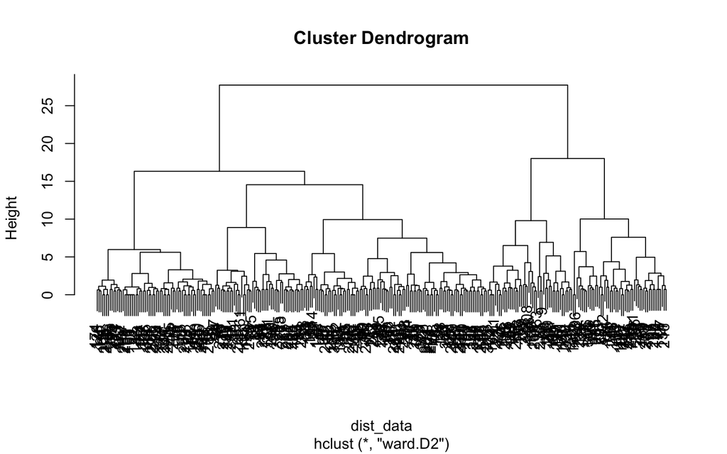

```r
# 1. 因子の尺度データの作成
data$熟慮 <- (6-data$Q1 + data$Q2) / 2
data$先延ばし <- (data$Q3 + data$Q4) / 2
data$他者参照 <- (data$Q5 + data$Q6) / 2
data$不安 <- (6-data$Q7 + data$Q8) / 2

# 2. 階層的クラスタリング
data_std <- data[c("熟慮", "先延ばし", "他者参照", "不安")]
dist_data <- dist(data_std)
hc <- hclust(dist_data, method="ward.D2")
plot(hc)
```

```r
## エルボー法
library(factoextra)
```

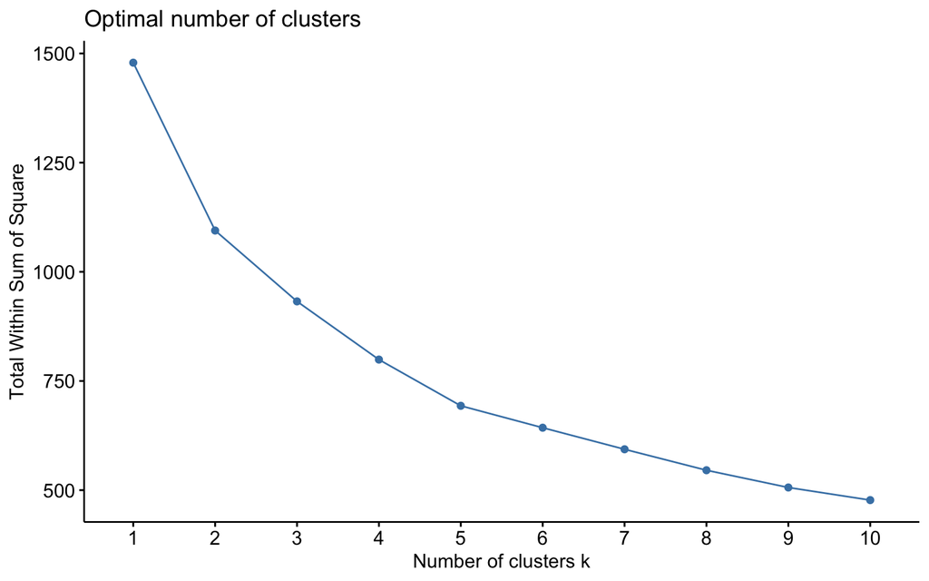

```r
fviz_nbclust(data_std, hcut, method="wss")
```

```r
# 3. クラスター分け
cluster_res <- cutree(hc, k=3)
table(cluster_res)
```

[output not shown]

[figure not shown]

```r
# 4. クラスターの特徴
data$cluster_res <- cluster_res
data$m熟慮 <- data$熟慮 - mean(data$熟慮)
data$m先延ばし <- data$先延ばし - mean(data$先延ばし)
data$m他者参照 <- data$他者参照 - mean(data$他者参照)
data$m不安 <- data$不安 - mean(data$不安)

df <- pivot_longer(data,
        cols = c("m熟慮", "m先延ばし", "m他者参照", "m不安"),
        names_to = "因子",
        values_to = "値")

ggplot(df,aes(x=因子, y=値,fill=因子)) +
  geom_bar( stat="summary", fun.data = mean_se) +
  theme(axis.text.x = element_text(angle = 90, hjust = 1, vjust = 0.5)) + # x軸のラベルを縦向きに
  facet_wrap(~cluster_res, nrow=1)
```

```r
# 5. k-means法
set.seed(13)
kmeans_res <- kmeans(data_std, centers=3, nstart=25)

data$cluster_res_kmeans <- kmeans_res$cluster
table(data$cluster_res_kmeans)
```

```
##
##   1   2   3
##  78 134  96
```

[figure not shown]

```r
data$m熟慮 <- data$熟慮 - mean(data$熟慮)
data$m先延ばし <- data$先延ばし - mean(data$先延ばし)
data$m他者参照 <- data$他者参照 - mean(data$他者参照)
data$m不安 <- data$不安 - mean(data$不安)

df <- pivot_longer(data,
        cols = c("m熟慮", "m先延ばし", "m他者参照", "m不安"),
        names_to = "因子",
        values_to = "値")

ggplot(df,aes(x=因子, y=値,fill=因子)) +
  geom_bar( stat="summary", fun.data = mean_se) +
  theme(axis.text.x = element_text(angle = 90, hjust = 1, vjust = 0.5)) + # x軸のラベルを縦向きに
  facet_wrap(~cluster_res_kmeans, nrow=1)
```